# Tidy and collection follow-up data

```r
library(tidyverse)
library(here)
library(cowplot)
library(pheatmap)
library(splots)
library(patchwork)
library(synergyfinder)
library(ggsignif)
library(broom)
library(ggrepel)
library(readxl)
library(platetools)
library(PharmacoGx)
#library(ggridges)
library(reshape2)
```

## load data

```r
#source(here::here("src/data/make_ctg_data.R"))
#source(here::here("src/data/"))

ctg_data <- read_csv(here::here("data/processed/ctg_data.csv"))
ctg_loess <- read_csv(here::here("data/processed/ctg_loess.csv"))
ctg_norm <- read_csv(here::here("data/processed/ctg_norm.csv"))
syn_table <- read_csv(here::here("data/processed/synergy_input.csv"))
syn_scores <- read_csv(here::here("data/processed/synergy_scores.csv"))
```

First, I get an overview of the dataset.

```r
pdf(file = "overview_valid_raw.pdf", width = 15, height = 4, compress = FALSE)
ctg_data %>%
  select(id, pcount) %>% arrange(id) %>% split(., .$id) %>% lapply(., function(f) f$pcount %>% as.vector) %>%
  plotScreen(., 10, do.names = TRUE, do.legend = FALSE)
dev.off()
```

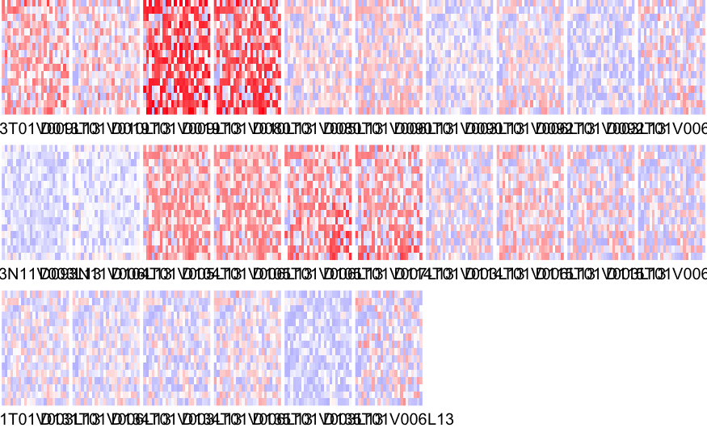

```r
ctg_data %>%
  select(id, pcount) %>% arrange(id) %>% split(., .$id) %>% lapply(., function(f) f$pcount %>% as.vector) %>%
  plotScreen(., 10, do.names = TRUE, do.legend = FALSE)
```

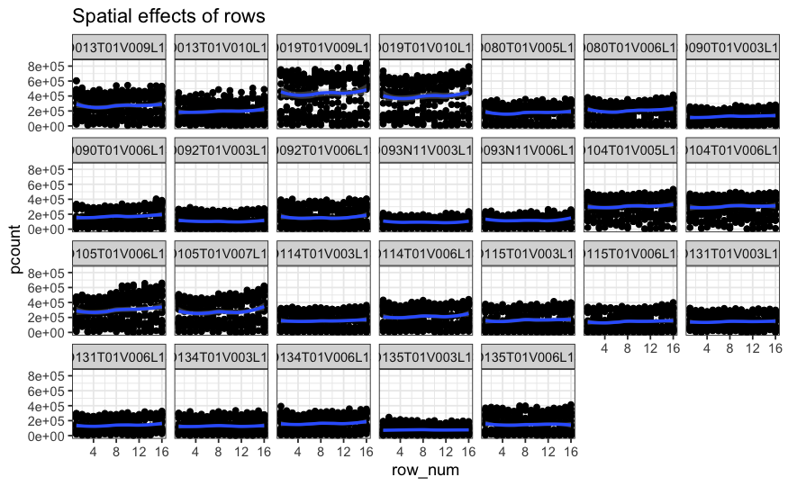

```r
ctg_data %>% ggplot(aes(row_num, pcount)) + geom_point() +
  geom_smooth() +
  facet_wrap(~id, nrow = 4) + theme_bw() + ggtitle("Spatial effects of rows")
```

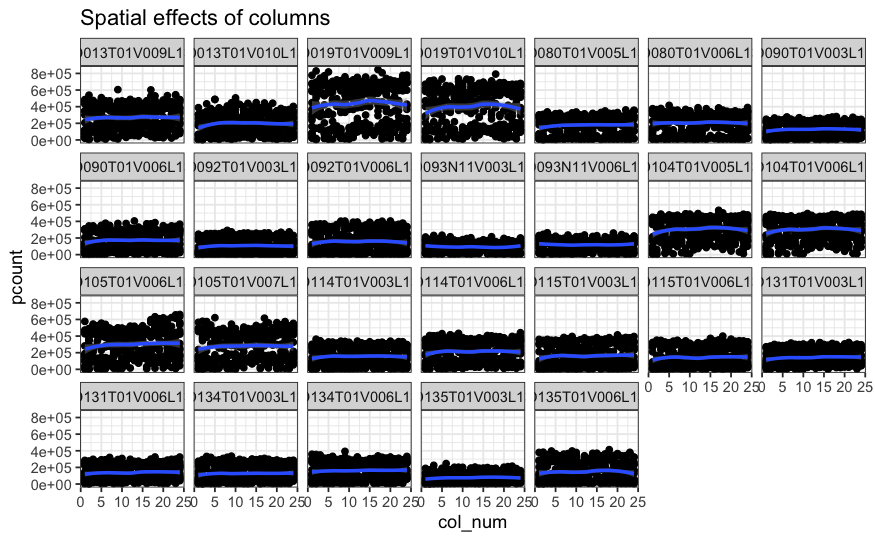

```r
  #next figure
  ctg_data %>% ggplot(aes(col_num, pcount)) + geom_point() +
  geom_smooth() +
  facet_wrap(~id, nrow = 4) + theme_bw() + ggtitle("Spatial effects of columns")
```

I applied a conservative loess fit for both columns and rows. I plot the results for rows and columns below.

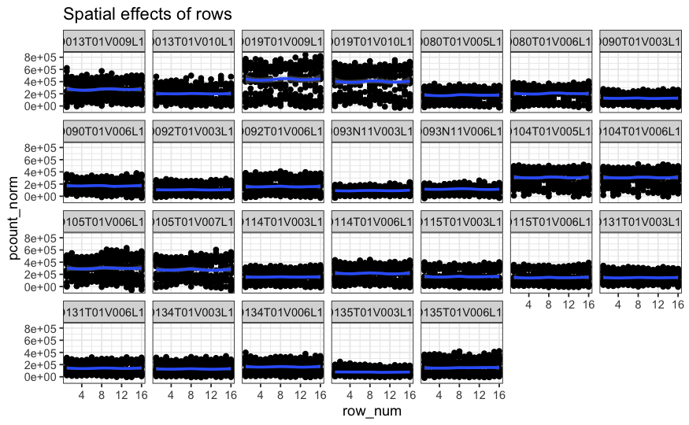

```r
ctg_loess %>% ggplot(aes(row_num, pcount_norm)) + geom_point() +
  geom_smooth() +
  facet_wrap(~id, nrow = 4) + theme_bw() + ggtitle("Spatial effects of rows")
```

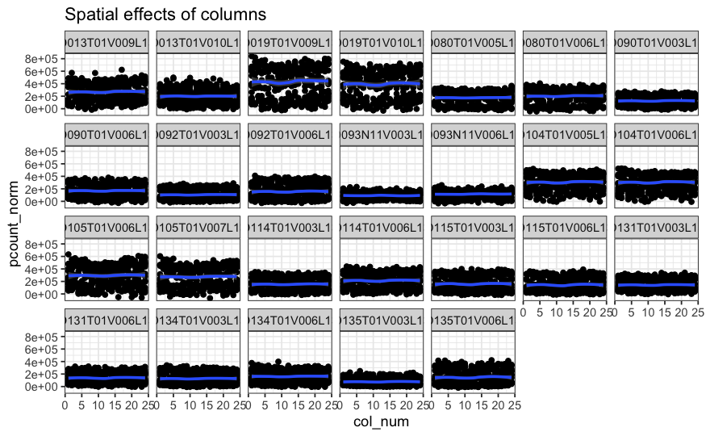

```r
  #next figure
  ctg_loess %>% ggplot(aes(col_num, pcount_norm)) + geom_point() +
  geom_smooth() +
  facet_wrap(~id, nrow = 4) + theme_bw() + ggtitle("Spatial effects of columns")
```

```r
pdf(file = "overview_valid_norm.pdf", width = 15, height = 4, compress = FALSE)
ctg_loess %>%
  select(id, pcount_norm) %>% arrange(id) %>% split(., .$id) %>% lapply(., function(f) f$pcount_norm %>% as.vector) %>%
  plotScreen(., 10, do.names = TRUE, do.legend = FALSE)
dev.off()
```

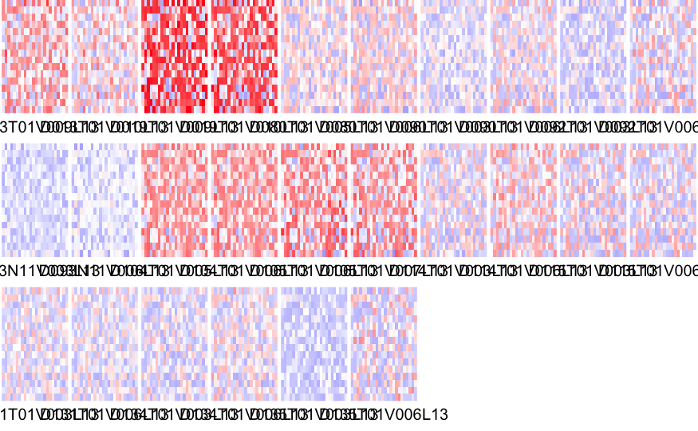

```r
ctg_loess %>%
  select(id, pcount_norm) %>% arrange(id) %>% split(., .$id) %>% lapply(., function(f) f$pcount_norm %>% as.vector) %>%
  plotScreen(., 10, do.names = TRUE, do.legend = FALSE)
```

# QC

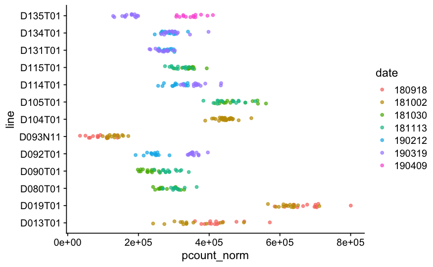

```r
coi <- c("DMSO")

ctg_loess %>%
  mutate(date = as.character(date)) %>%
  filter(drug_1 %in% coi & drug_2 %in% coi) %>%
  ggplot(aes(line, pcount_norm, color = date)) +
  #geom_violin(aes(group = drug)) +
  geom_jitter(alpha = 0.7, width = 0.1) +
  #geom_boxplot(width = 30) +
  #facet_wrap(~line) +
  theme_cowplot() +
  coord_flip()
```

```r
# ctg_loess %>%
#   mutate(line_date_exp = paste0(line, "_", date)) %>%
#   filter(drug %in% coi) %>%
#   filter(combination == TRUE) %>%
#   ggplot(aes(id, pcount_norm, color = drug)) +
#   #geom_violin(aes(group = drug)) +
#   geom_boxplot(alpha = 0.7) +
#   #facet_grid(line_date_exp ~ Library) +
#   #facet_wrap(~line) +
#   theme_classic()
```

There are both line and replicate level differences in viability. I normalize on a plate level. Before I move on, I plot the distribution of photnon counts for each plate.

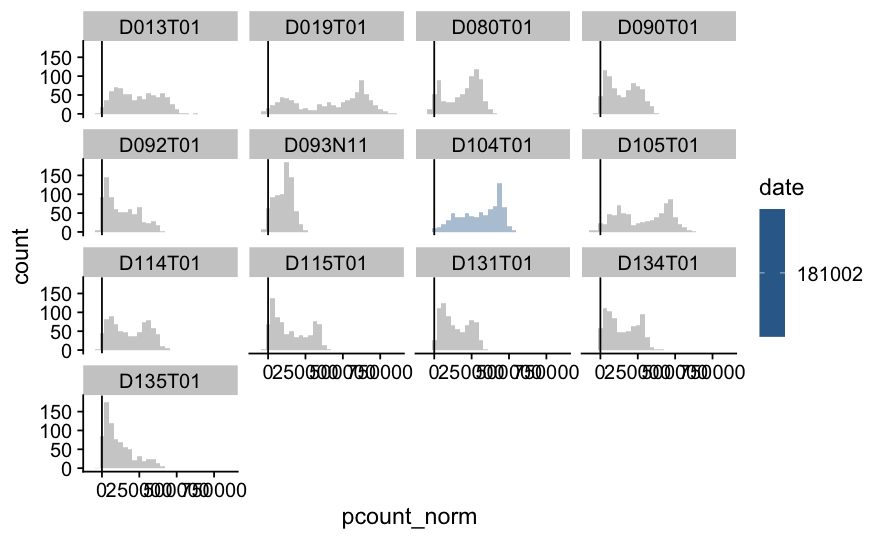

```r
ctg_loess %>%
  ggplot(aes(pcount_norm, fill = date)) +
  #geom_violin(aes(group = drug)) +
  geom_histogram(position="identity", alpha = 0.4) +
  #geom_boxplot(width = 30) +
  facet_wrap(~line) +
  theme_cowplot() +
  geom_vline(xintercept = 0)
```

I expect the highest concentration of taxanes to be completely lethal.

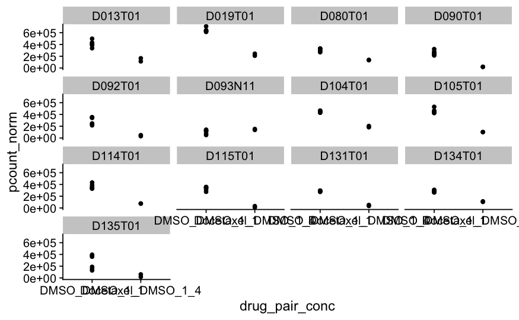

```r
coi <- c("Docetaxel_DMSO", "DMSO_DMSO")

ctg_loess %>%
  filter(drug %in% coi) %>%
  filter(conc_1 == 1) %>%
  ggplot(aes(drug_pair_conc, pcount_norm)) +
  geom_point() +
  facet_wrap(~ line) +
  theme_cowplot()
```

I calculate z-factors, as a reference point, I select the highest concentration pair

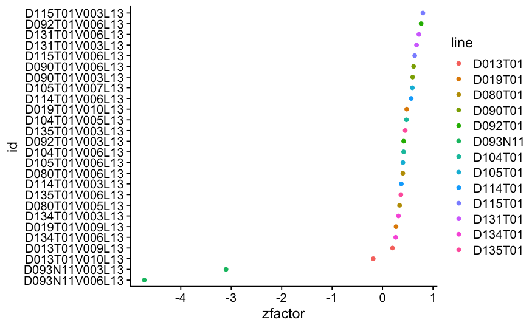

```r
coi <- c("Docetaxel_DMSO", "DMSO_DMSO")

z_df <- ctg_loess %>%
  filter(drug %in% coi) %>%
  filter(!(drug == coi[1] & conc_1 %in% c(3:5))) %>%
  group_by(id, drug, line, date) %>%
  summarise(sd = sd(pcount_norm, na.rm = TRUE),
            mean = mean(pcount_norm, na.rm = TRUE)) %>%
  group_by(id, line, date) %>%
  summarise(zfactor = 1-((3*sum(sd))/abs(range(mean)[1]-range(mean)[2]))) %>%
  mutate(qc = if_else(zfactor < 0.25, FALSE, TRUE))
z_df %>%
  arrange(zfactor) %>%
  ungroup() %>%
  mutate(id = factor(id, levels = id)) %>%
  ggplot(aes(zfactor, id)) +
  geom_point(aes(color =  line)) +
  theme_cowplot()
```

```r
# z_df_anno <- z_df %>% ungroup%>% mutate(id = paste0(id, "_", combination)) %>%
#   dplyr::select(-experiment, -zfactor) %>%
#   as.data.frame() %>%
#   remove_rownames() %>%
#   column_to_rownames("id")
#
# z_df %>% ungroup%>% mutate(id = paste0(id, "_", combination)) %>% dplyr::select(id, zfactor) %>%
#   arrange(zfactor) %>%
#   as.data.frame() %>%
#   remove_rownames() %>%
#   column_to_rownames("id") %>%
#   pheatmap(., cluster_cols = FALSE, annotation_row =  z_df_anno)
```

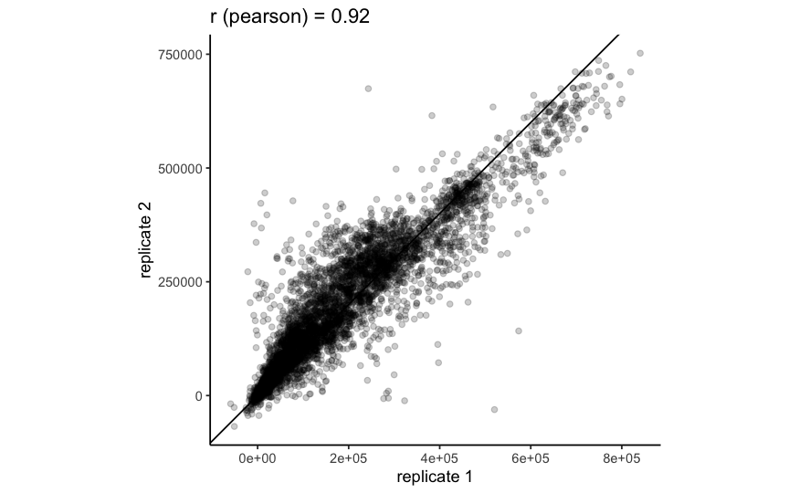

```r
r <- ctg_loess %>%
  mutate(ctrl = ifelse(drug == "DMSO", "negative", "none")) %>%
  mutate(ctrl = ifelse(drug == "Docetaxel_DMSO" & conc_1 %in% c(1:2), "positive", ctrl)) %>%
  #filter(drug %in% coi) %>%
  unite(id, c("line", "well")) %>%
  dplyr::select(id, pcount_norm, replicate) %>%
  spread(replicate, pcount_norm) %>%
  rename(rep1 = `1`) %>%
  rename(rep2 = `2`) %>%
  dplyr::select(rep1, rep2) %>%
  as.matrix() %>%
  cor() %>%
  .["rep1", "rep2"]

df <- ctg_loess %>%

  mutate(ctrl = ifelse(drug == "DMSO", "negative", "none")) %>%
  mutate(ctrl = ifelse(drug == "Docetaxel_DMSO" & conc_1 %in% c(1:2), "positive", ctrl)) %>%
  #filter(drug %in% coi) %>%
  unite(id, c("line", "well")) %>%
  dplyr::select(id, pcount_norm, replicate) %>%
  spread(replicate, pcount_norm) %>%
  rename(rep1 = `1`) %>%
  rename(rep2 = `2`)

df  %>% write_csv(here::here("reports/plot_data/pearson_raw_valid.csv"))

df %>%
  ggplot(aes(rep1, rep2)) +
  geom_point(alpha = 0.2) +
  #geom_point(alpha = 0.2, aes(color = ctrl)) +
  #scale_color_manual(values=c("#E69F00", "#999999", "#56B4E9")) +
  geom_abline(intercept = 0, slope = 1) +
  #geom_hline(yintercept = 1) +
  theme_classic() +
  ggtitle(paste0("r (pearson) = ", r %>% round(2))) +
  xlab("replicate 1") +
  ylab("replicate 2") +
  scale_y_continuous(breaks = c(0, 250000, 500000, 750000)) +
  coord_fixed() +
  ggsave(here::here("reports/figures/pearson_raw_valid.pdf"), width = 4, height = 4)
```

```r
NA
NA
```

#Normalization

At first glance, the majority of the screen is well behaved. I performed plate-wise noramlization to see wether I can also recover plates with differring plates.

I plot the correlation again.

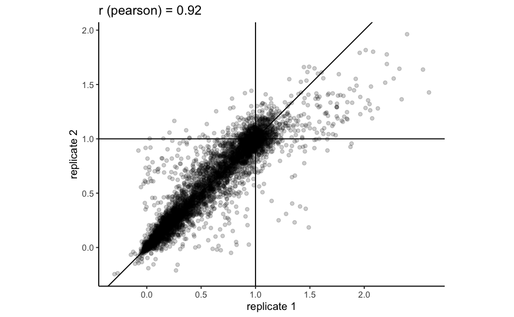

```r
r <- ctg_norm %>%
  mutate(ctrl = ifelse(drug == "DMSO_DMSO", "negative", "none")) %>%
  mutate(ctrl = ifelse(drug == "Docetaxel_DMSO" & conc_1 %in% c(1:2), "positive", ctrl)) %>%
  #filter(drug %in% coi) %>%
  unite(id, c("line", "well")) %>%
  dplyr::select(id, viability, replicate) %>%
  spread(replicate, viability) %>%
  rename(rep1 = `1`) %>%
  rename(rep2 = `2`) %>%
  dplyr::select(rep1, rep2) %>%
  as.matrix() %>%
  cor() %>%
  .["rep1", "rep2"]

df <- ctg_norm %>%
  mutate(ctrl = ifelse(drug == "DMSO", "negative", "none")) %>%
  mutate(ctrl = ifelse(drug == "Docetaxel_DMSO" & conc_1 %in% c(1:2), "positive", ctrl)) %>%
  #filter(drug %in% coi) %>%
  unite(id, c("line", "well")) %>%
  dplyr::select(id, viability_uncropped, replicate) %>%
  spread(replicate, viability_uncropped) %>%
  rename(rep1 = `1`) %>%
  rename(rep2 = `2`)

df %>% write_csv(here::here("reports/plot_data/pearson_norm_valid.csv"))

df %>%
  ggplot(aes(rep1, rep2)) +
  geom_point(alpha = 0.2) +
  #geom_point(alpha = 0.2, aes(color = ctrl)) +
  #scale_color_manual(values=c("#E69F00", "#999999", "#56B4E9")) +
  geom_abline(intercept = 0, slope = 1) +
  #geom_hline(yintercept = 1) +
  theme_classic() +
  ggtitle(paste0("r (pearson) = ", r %>% round(2))) +
  xlab("replicate 1") +
  ylab("replicate 2") +
  scale_y_continuous(breaks = c(0, 0.5, 1, 1.5,2)) +
  scale_x_continuous(breaks = c(0, 0.5, 1, 1.5,2)) +
  geom_hline(yintercept = 1) +
  geom_vline(xintercept = 1) +
  coord_fixed() +
  ggsave(here::here("reports/figures/pearson_norm_valid.pdf"), width = 4, height = 4)
```

```r
NA
```

To avoid the simpson paradox, I also plot line-wise correlations.

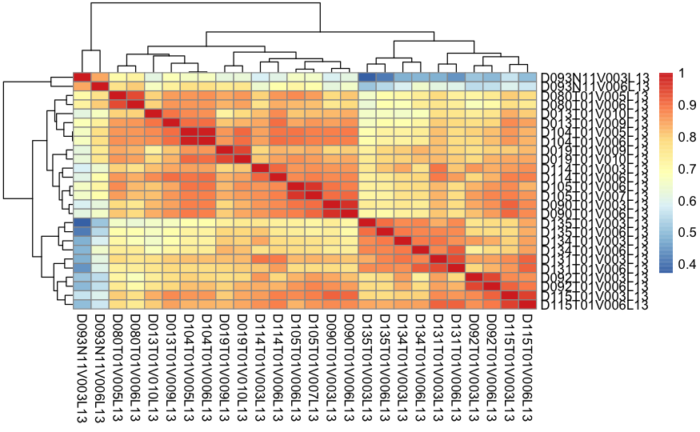

```r
ctg_norm %>%
  dplyr::select(id, viability, well) %>%
  spread(id, viability) %>%
  dplyr::select(-well) %>%
  as.matrix() %>%
  cor() %>%
  pheatmap::pheatmap()
```

Synergy calculations are missled in cases where are treatment is actually boosting overall viability. Because of this effect, I set the maximum viability to 1.

```r
ctg_norm <- ctg_norm %>%
  mutate(viability = if_else(viability > 1, 1, viability))
```

# Calculating synergy scores

I consider using the “synergyfinder” package, published by He et al. at the FIMM. First I wrangled the data into a standardized input format.

I perform a sanity check after preparing the data for synergy exploration.

```r
f <- syn_table %>% filter(block_id == "Everolimus_AZD5363", line == "D013T01", replicate == 1) %>%
  ungroup() %>%
  dplyr::select(-replicate)

# trouble shooting
# me = c("ZIP", "HSA", "Bliss", "Loewe")
# m = me[1]
f
```

| block_id | drug_row | drug_col | Row | Col | conc_r | conc_c | conc_r_unit | line | response | conc_c_unit |
| --- | --- | --- | --- | --- | --- | --- | --- | --- | --- | --- |
| Everolimus_AZD5363 | AZD5363 | DMSO | 6 | 1 | 0.000 | 10.000 | uM | D013T01 | 60.43810 | uM |
| Everolimus_AZD5363 | AZD5363 | DMSO | 6 | 2 | 0.000 | 2.000 | uM | D013T01 | 62.56926 | uM |
| Everolimus_AZD5363 | AZD5363 | DMSO | 6 | 3 | 0.000 | 0.400 | uM | D013T01 | 95.11740 | uM |
| Everolimus_AZD5363 | AZD5363 | DMSO | 6 | 4 | 0.000 | 0.080 | uM | D013T01 | 116.41224 | uM |
| Everolimus_AZD5363 | AZD5363 | DMSO | 6 | 5 | 0.000 | 0.016 | uM | D013T01 | 101.35022 | uM |
| Everolimus_AZD5363 | DMSO | DMSO | 6 | 6 | 0.000 | 0.000 | uM | D013T01 | 100.00000 | uM |
| Everolimus_AZD5363 | Everolimus | AZD5363 | 1 | 1 | 10.000 | 10.000 | uM | D013T01 | 57.09572 | uM |
| Everolimus_AZD5363 | Everolimus | AZD5363 | 1 | 2 | 10.000 | 2.000 | uM | D013T01 | 52.00934 | uM |
| Everolimus_AZD5363 | Everolimus | AZD5363 | 1 | 3 | 10.000 | 0.400 | uM | D013T01 | 66.71848 | uM |
| Everolimus_AZD5363 | Everolimus | AZD5363 | 1 | 4 | 10.000 | 0.080 | uM | D013T01 | 72.38531 | uM |

[output cut: 26 more lines]

I visaulize the matrix of responses

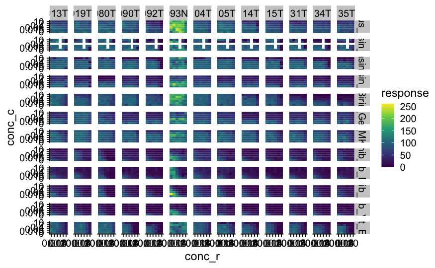

```r
syn_table %>% filter(replicate ==1) %>%
  mutate(conc_r = factor(conc_r),
         conc_c = factor(conc_c)) %>%
  ggplot(aes(conc_r, conc_c, fill = response)) +
  geom_tile() +
  scale_fill_viridis_c() +
  facet_grid(block_id ~ line) +
  theme_cowplot()+
  ggsave("response_overview.pdf", height = 15, width = 17)
```

```r
# syn_table shows the missing data
syn_table %>%
  group_by(block_id) %>%
  summarise(n = n()) %>%
  filter(n != max(n))
```

| block_id | n |
| --- | --- |
| Napabucasin_Rucaparib | 676 |

```r
# ctg_norm is not ok
ctg_data %>%
  mutate(block_id = paste(drug, sep = "_")) %>%
  group_by(block_id) %>%
  summarise(n = n()) %>%
  count(n)
```

```
Storing counts in `nn`, as `n` already present in input
ℹ Use `name = "new_name"` to pick a new name.
```

| n | nn |
| --- | --- |
| 104 | 1 |
| 130 | 15 |
| 364 | 1 |
| 416 | 1 |
| 650 | 11 |

```r
# I filter n = 130, 104, 416
ctg_data %>%
  mutate(block_id = paste(drug, sep = "_")) %>%
  group_by(block_id) %>%
  summarise(n = n()) %>%
  filter(n %in% c(364, 104, 416))
```

| block_id | n |
| --- | --- |
| DMSO_DMSO | 364 |
| Napabucasin_Rucaparib | 416 |
| Rucaparib_DMSO | 104 |

It seems like these combinations are not in the raw data. I check the annotation table.

```r
read_csv(here("anno/combi_validation_robot.csv")) %>%
  separate(drug_pair_conc, c("drug_1", "drug_2", "conc_1", "conc_2"),
           remove = FALSE, sep = "_") %>%
  mutate(block_id = paste(drug, sep = "_")) %>%
  group_by(block_id) %>%
  summarise(n = n())
```

| block_id | n |
| --- | --- |
| Afatinib | 30 |
| AZD5363 | 30 |
| Birinapant | 30 |
| DMSO | 79 |
| Docetaxel | 30 |
| EHMT-Inh. | 30 |
| Everolimus | 30 |
| Gefitinib | 30 |
| MK8776 | 30 |
| NA | 14 |

[output cut: 8 more lines]

## synergy calculation

Now having this wrangled dataframe and an own function in place, I calculated synergies by calling the “calculate_synergy.R” script.

After the values have been calculated I go on and check the distribution of scores.

[output not shown]

[output cut: 990 more lines]

I wonder it synergy scores correlated well between replicates.

[figure not shown]

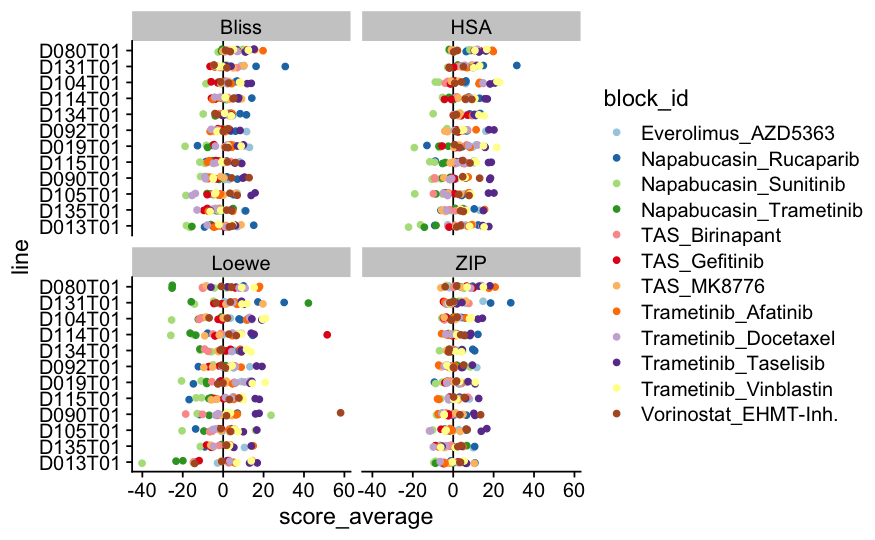

```r
order_line <- syn_scores %>%
  filter(line != "D093N11") %>%
  group_by(line) %>%
  summarise(mean = mean(score_average)) %>%
  arrange(mean) %>%
  .$line
syn_scores %>%
  filter(line != "D093N11") %>%
  mutate(line = factor(line, levels = order_line)) %>%
  ggplot(aes(score_average, line, color = block_id)) +
  geom_vline(xintercept = 0) +
  geom_jitter(height = 0.1, width = 0.1) +
  facet_wrap(~ method ) +
  theme_cowplot() +
  scale_colour_brewer(type = "qual", palette = 3)
```

```r
syn_collapsed <- syn_scores %>%
  filter(line != "D093N11") %>%
  filter(block_id != "Vorinostat_EHMT-Inh.") %>%
  group_by(block_id, method, line) %>%
  summarise(score = mean(score_average))
syn_collapsed %>% write_csv(here("data/processed/synergy_simplified.csv"))

# lm(score ~ block_id, data = syn_collapsed %>% filter(method == "ZIP")) %>% summary()
# lm(score ~ block_id, data = syn_collapsed %>% filter(method == "Bliss")) %>% summary()
# lm(score ~ block_id, data = syn_collapsed %>% filter(method == "Loewe")) %>% summary()
# lm(score ~ block_id, data = syn_collapsed %>% filter(method == "HSA")) %>% summary()

lm(score ~ block_id + method, data = syn_collapsed) %>% summary()
```

```
Call:
lm(formula = score ~ block_id + method, data = syn_collapsed)

Residuals:
     Min       1Q   Median       3Q      Max
-21.4577  -3.4341   0.2065   3.5199  24.7863

Coefficients:
                               Estimate Std. Error t value Pr(>|t|)
(Intercept)                      3.2876     0.9648   3.407 0.000707 ***
block_idNapabucasin_Rucaparib   -0.1377     1.2095  -0.114 0.909373
block_idNapabucasin_Sunitinib  -11.1920     1.2095  -9.254  < 2e-16 ***
block_idNapabucasin_Trametinib  -7.9707     1.2095  -6.590 1.09e-10 ***
block_idTAS_Birinapant          -6.0555     1.2095  -5.007 7.62e-07 ***
block_idTAS_Gefitinib           -5.2881     1.2095  -4.372 1.49e-05 ***
block_idTAS_MK8776              -4.0728     1.2095  -3.367 0.000816 ***
block_idTrametinib_Afatinib     -0.4831     1.2095  -0.399 0.689711
block_idTrametinib_Docetaxel    -3.1091     1.2095  -2.571 0.010431 *
block_idTrametinib_Taselisib     6.4607     1.2095   5.342 1.38e-07 ***
block_idTrametinib_Vinblastin    1.3658     1.2095   1.129 0.259316
methodHSA                        3.7788     0.7293   5.181 3.17e-07 ***
methodLoewe                      0.9537     0.7293   1.308 0.191563
methodZIP                        0.3500     0.7293   0.480 0.631538
---
Signif. codes:  0 ‘***’ 0.001 ‘**’ 0.01 ‘*’ 0.05 ‘.’ 0.1 ‘ ’ 1

Residual standard error: 5.925 on 514 degrees of freedom
Multiple R-squared:  0.412, Adjusted R-squared:  0.3971
F-statistic:  27.7 on 13 and 514 DF,  p-value: < 2.2e-16
```

I wonder if certain subtypes are becoming obvious

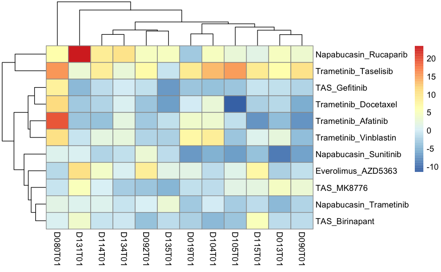

```r
syn_collapsed %>%
  ungroup() %>%
  filter(method == "ZIP") %>%
  dplyr::select(line, score, block_id, -method) %>%

  spread(line, score) %>%
  as.data.frame() %>%
  column_to_rownames("block_id") %>%
  pheatmap::pheatmap()
```

```r
set.seed(1234)

model_estimate <- lm(score ~ block_id + method, data = syn_collapsed %>% filter(line != "D093N11")) %>% broom::tidy() %>%
  mutate(q = p.adjust(p.value, method = "bonferroni")) %>%
  filter(q < 0.05, grepl(pattern = "block", x = term)) %>%
  mutate(term = substr(term, 9, nchar(term))) %>%
  arrange(desc(estimate))

model_estimate %>% write_csv(here::here("reports/tables/lm_synergy.csv"))

model_estimate
```

| term | estimate | std.error | statistic | p.value | q |
| --- | --- | --- | --- | --- | --- |
| Trametinib_Taselisib | 6.460718 | 1.209462 | 5.341812 | 1.384660e-07 | 1.938524e-06 |
| TAS_MK8776 | -4.072761 | 1.209462 | -3.367416 | 8.156263e-04 | 1.141877e-02 |
| TAS_Gefitinib | -5.288100 | 1.209462 | -4.372275 | 1.488928e-05 | 2.084500e-04 |
| TAS_Birinapant | -6.055515 | 1.209462 | -5.006784 | 7.618128e-07 | 1.066538e-05 |
| Napabucasin_Trametinib | -7.970651 | 1.209462 | -6.590246 | 1.089759e-10 | 1.525662e-09 |
| Napabucasin_Sunitinib | -11.191961 | 1.209462 | -9.253670 | 5.826188e-19 | 8.156663e-18 |

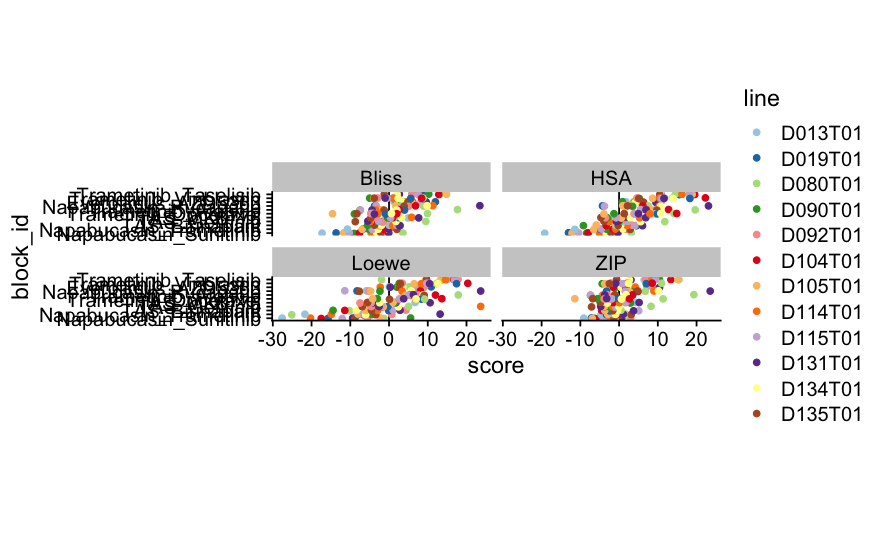

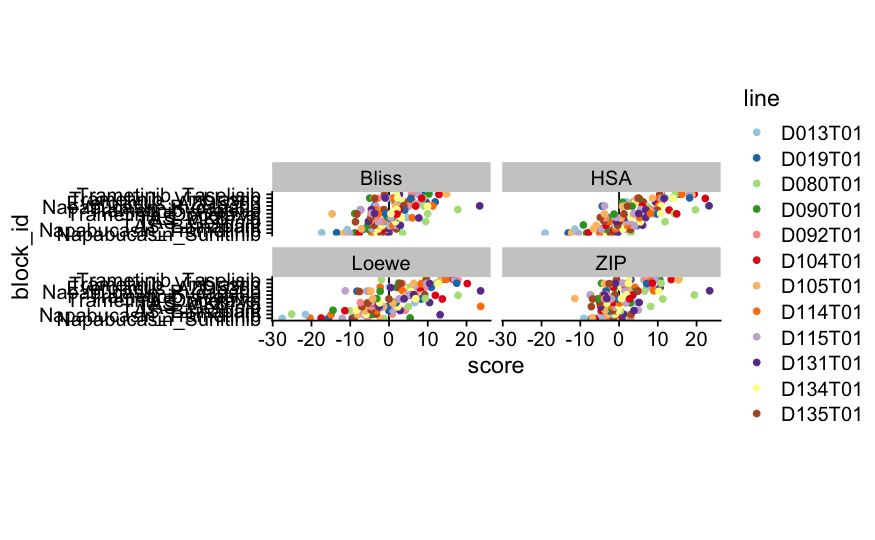

```r
syn_collapsed %>%
    ungroup() %>%
    filter(line != "D093N11") %>%
    mutate(block_id = factor(block_id, levels = order)) %>%
    ggplot(aes(score, block_id, color = line)) +
    geom_vline(xintercept = 0) +
    geom_jitter(height = 0.1, width = 0.1) +
    facet_wrap(~ method ) +
    theme_cowplot() +
    scale_colour_brewer(type = "qual", palette = 3) +
    coord_fixed() +
    ggsave(here::here("reports/figures/synergy_line.pdf"))
syn_collapsed %>%
  ungroup() %>%
filter(line != "D093N11") %>%
  mutate(block_id = factor(block_id, levels = order)) %>%
  ggplot(aes(score, block_id, color = line)) +
  geom_vline(xintercept = 0) +
  geom_jitter(height = 0.1, width = 0.1) +
  facet_wrap(~ method ) +
  theme_cowplot() +
  scale_colour_brewer(type = "qual", palette = 3) +
  coord_fixed() +
  ggsave(here::here("reports/figures/synergy_line.pdf"))
```